# Lab 11

April 9/10 2020

## Follow-up tests (univariate), model comparison (mixed-effects), and basic linear algebra operations

## Load the data

```r
# Same data from Lab 9 and Lab 10
library(tidyverse)
library(ez)
library(lme4)
library(effects)
library(emmeans)

# Making sure we have ANOVA-appropriate contrasts:
options(contrasts = c("contr.sum","contr.poly"))

# sleepstudy data from lme4 package
data(sleepstudy)
sleep <- sleepstudy %>%
  mutate(Days = factor(sleepstudy$Days, ordered = TRUE))

# Data from "Modeling the dynamics of recognition memory
# testing with a combined model of retrieval and
# decision making
mem_dat <- read_csv("exp1testing.csv") %>%
  mutate_if(is.character, factor) %>%
  mutate(subj = factor(subj),
         RT = log(RT))
```

## Create an age factor (old = 0, young = 1)

```r
# Compute subject * condition aggregate means
grp_mem_dat <- mem_dat %>%
  group_by(subj, wf, block) %>%
  summarize(mean_rt = mean(RT))

subj <- grp_mem_dat %>%
  arrange(desc(mean_rt)) %>%
  ungroup() %>%
  select(subj) %>%
  unique() %>%
  filter(subj != 0)

is_young <- rep(c(0, 1), each = nrow(subj) / 2) %>%
  factor()
joiner <- cbind(subj, is_young)

age_dat <- mem_dat %>%
  inner_join(joiner, by = "subj")
```

## Follow-up tests (univariate)

## Specify the aov model

```r
aov_fact <- aov(mean_rt ~ wf * block +
               Error(subj/(wf * block)),
               data = grp_mem_dat)
```

## View aov solution

```r
summary(aov_fact)
```

```
##
## Error: subj
##            Df Sum Sq Mean Sq F value Pr(>F)
## Residuals 106  20.66   0.195
##
## Error: subj:wf
##            Df Sum Sq Mean Sq F value Pr(>F)
## wf          1  1.115  1.1151   107.6 <2e-16 ***
## Residuals 106  1.099  0.0104
## ---
## Signif. codes:  0 '***' 0.001 '**' 0.01 '*' 0.05 '.' 0.1 ' ' 1
##
## Error: subj:block
##            Df Sum Sq Mean Sq F value Pr(>F)
## block       3  0.096 0.03211   3.088 0.0274 *
## Residuals 318  3.307 0.01040
## ---
## Signif. codes:  0 '***' 0.001 '**' 0.01 '*' 0.05 '.' 0.1 ' ' 1
##
## Error: subj:wf:block
##            Df Sum Sq Mean Sq F value Pr(>F)
## wf:block    3 0.0185 0.00616   1.625  0.183
## Residuals 318 1.2052 0.00379
```

## Run follow-up tests on aov object

```r
full <- emmeans(aov_fact, ~ block|wf)
main_block <- emmeans(aov_fact, ~ block)
main_wf <- emmeans(aov_fact, ~ wf)

# If interaction is significant, test simple effects
full_tests <- contrast(full, interaction = TRUE,
                       method = "trt.vs.ctrl",
                       adjust = "bonferroni")

# If interaction is not significant, test contrasts of
# interest at main effect
block_test <- contrast(main_block,
                       method = "trt.vs.ctrl",
                       ref = 4,
                       adjust = "bonferroni")
wf_test <- contrast(main_wf,
                    method = "trt.vs.ctrl",
                    adjust = "bonferroni")
```

## Interaction comparisons

```r
full_tests
```

```
## wf = HF:
##  block_trt.vs.ctrl estimate     SE  df t.ratio p.value
##  b1 - b0            0.00591 0.0115 523 0.513   1.0000
##  b2 - b0            0.03259 0.0115 523 2.830   0.0145
##  b3 - b0            0.02423 0.0115 523 2.104   0.1075
##
## wf = LF:
##  block_trt.vs.ctrl estimate     SE  df t.ratio p.value
##  b1 - b0            0.01122 0.0115 523 0.975   0.9907
##  b2 - b0            0.01430 0.0115 523 1.242   0.6449
##  b3 - b0            0.02711 0.0115 523 2.354   0.0568
##
## P value adjustment: bonferroni method for 3 tests
```

## Block comparisons

```r
block_test
```

```
##  contrast estimate      SE  df t.ratio p.value
##  b0 - b3  -0.02567 0.00986 318 -2.604  0.0289
##  b1 - b3  -0.01711 0.00986 318 -1.735  0.2511
##  b2 - b3  -0.00223 0.00986 318 -0.226  1.0000
##
## Results are averaged over the levels of: wf
## P value adjustment: bonferroni method for 3 tests
```

## Specify the ezANOVA model

```r
# Specified type III sum of squares here
ez_mod <- ezANOVA(data = sleep,
                  dv = Reaction,
                  within = Days,
                  wid = Subject,
                  type = 3,
                  return_aov = TRUE,
                  detailed = TRUE
        )
summary(ez_mod)
```

```
##                               Length Class      Mode
## ANOVA                         9      data.frame list
## Mauchly's Test for Sphericity 4      data.frame list
## Sphericity Corrections        7      data.frame list
## aov                           3      aovlist    list
```

## Run follow-up tests on ez object

```r
full <- emmeans(ez_mod$aov, ~ Days)

all_pairs <- pairs(full, adjust = "bonferroni")

poly_cont <- contrast(full, method = "poly",
         adjust = "bonferroni")
```

## All ez pairwise comparisons

```r
all_pairs
```

```
##  contrast estimate   SE  df t.ratio p.value
##  0 - 1      -7.844 10.5 153 -0.749  1.0000
##  0 - 2      -8.710 10.5 153 -0.831  1.0000
##  0 - 3     -26.340 10.5 153 -2.515  0.5829
##  0 - 4     -31.998 10.5 153 -3.055  0.1197
##  0 - 5     -51.867 10.5 153 -4.951  0.0001
##  0 - 6     -55.526 10.5 153 -5.301  <.0001
##  0 - 7     -62.099 10.5 153 -5.928  <.0001
##  0 - 8     -79.978 10.5 153 -7.635  <.0001
##  0 - 9     -94.199 10.5 153 -8.993  <.0001
##  1 - 2      -0.866 10.5 153 -0.083  1.0000
##  1 - 3     -18.496 10.5 153 -1.766  1.0000
##  1 - 4     -24.154 10.5 153 -2.306  1.0000
##  1 - 5     -44.023 10.5 153 -4.203  0.0020
##  1 - 6     -47.682 10.5 153 -4.552  0.0005
```

[output cut: 33 more lines]

## Polynomial contrasts

```r
poly_cont
```

```
##  contrast  estimate    SE  df t.ratio p.value
##  linear      1727.1 134.6 153 12.835  <.0001
##  quadratic     89.0  85.1 153  1.046  1.0000
##  cubic        -65.3 686.1 153 -0.095  1.0000
##  quartic      314.9 396.1 153  0.795  1.0000
##  degree 5      49.0 206.9 153  0.237  1.0000
##  degree 6    -155.1 190.3 153 -0.815  1.0000
##
## P value adjustment: bonferroni method for 6 tests
```

## Specifying a subset of contrasts

```r
subset <- emmeans(ez_mod$aov, ~ Days,
        contr = list(
        "linear" = contrasts(sleep$Days)[, 1],
        "quadratic" = contrasts(sleep$Days)[, 2]
        ), adjust = "bonferroni"
  )
subset$contrasts
```

```
##  contrast  estimate   SE  df t.ratio p.value
##  linear       95.07 7.41 153 12.835  <.0001
##  quadratic     7.74 7.41 153  1.046  0.5949
##
## P value adjustment: bonferroni method for 2 tests
```

## Plot the ez model

```r
ez_plot <- ezPlot(
  data = sleep,
  dv = Reaction,
  wid = Subject,
  within = Days,
  x = Days,
  x_lab = "Days",
  y_lab = "RT"
  )

# help(ez_plot) for specifying more complex plots
```

## RT increases as a function of Days

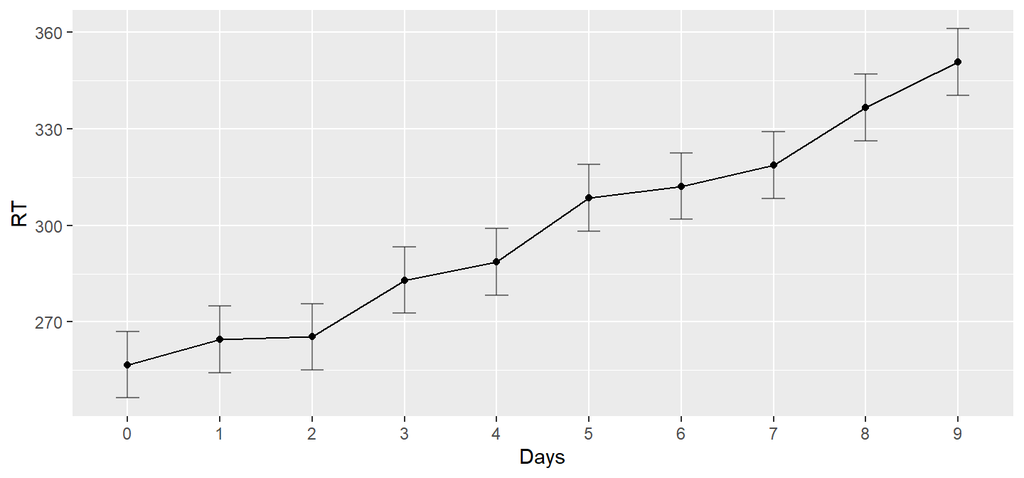

```r
ez_plot
```

## Model comparison using likelihoods with lmer

## First we need to fit an lmer model

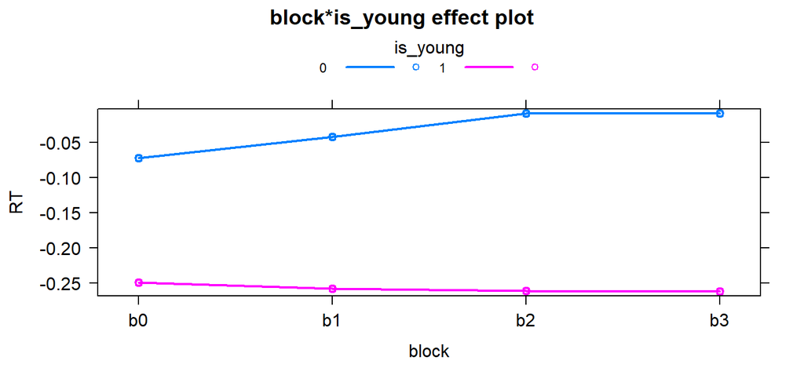

```r
full <- lmer(RT ~ block * is_young + (1|subj/block),
             REML = FALSE, data = age_dat)
plot(allEffects(full), multiline = TRUE)
```

## AIC and BIC

-AIC: Akaike information criterion (\(k = 2\))

-BIC: Bayesian information criterion (\(k = \textrm{ln}(n)\))

Let \(\hat{L}\) be the maximum likelihood estimate of the model, \(k\) the chosen penalization parameter, and \(df\) the number of parameters in the fitted model.

- The penalized likelihood function is expressed as follows

\[-2\textrm{ln}(\hat{L}) + k*df\]

By this formula, it is clear that lower values indicate evidence for "better" fit conditional on model complexity (\(df\)).

Note that \(-2\textrm{ln}(\hat{L})\) will never increase with the addition of parameters. In other words, adding parameters will always result in better fit.

## Model comparison in R

\[\textrm{BIC} = -2\textrm{ln}(\hat{L}) + \textrm{ln}(n)df\] \[\textrm{AIC} = -2\textrm{ln}(\hat{L}) + 2df\]

```r
# BIC (more conservative for n > 7)
bic_by_hand <- -2 * as.numeric(logLik(full)) +
  log(nobs(full)) * attr(logLik(full), "df")

# AIC (less conservative for n > 7)
aic_by_hand <- -2 * as.numeric(logLik(full)) +
  2 * attr(logLik(full), "df")

BIC(full) == bic_by_hand & AIC(full) == aic_by_hand
```

```
## [1] TRUE
```

## Sample size and penalty parameter with BIC

```r
logs <- data.frame(samp = seq(1, 1e5),
                        log_samp = log(seq(1, 1e5)))

plot_logs <- logs %>%
  ggplot(aes(x = samp, y = log_samp)) +
  geom_line(color = "cyan3") +
  geom_hline(yintercept = 2,
    linetype = "dashed", color = "darkseagreen1") +
  geom_hline(yintercept = max(logs$log_samp),
    linetype = "dashed", color = "cyan3") +
  annotate(geom = "text",
           label = "AIC penalty (k = 2)",
           x = max(logs$samp) / 2,
           y = 3,
           color = "darkseagreen1") +
  annotate(geom = "text",
           label = "BIC penalty (k = log(n))",
           x = max(logs$samp) / 2,
           y = .85 * max(logs$log_samp),
           color = "cyan3") +
  labs(x = "Sample size", y = "Penalty parameter (k)") +
  theme_dark()
```

## BIC is more conservative than AIC

BIC increases logarithmically as \(n\to\infty\)

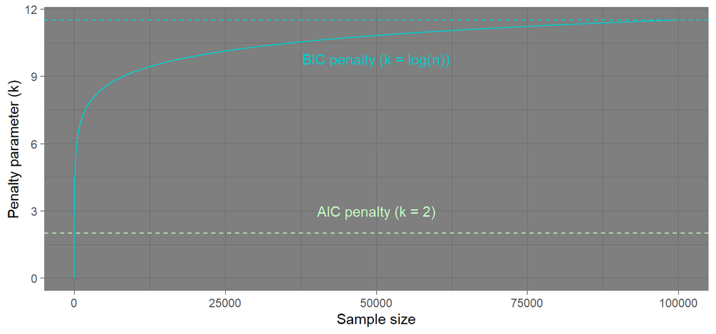

```r
plot_logs
```

## Comparing models with parameters

```r
# REML = FALSE is necessary for comparing models
# Update your final model with REML = TRUE
null_mod <- lmer(RT ~ 1 + (1|subj/block),
                 REML = FALSE, data = age_dat)

main_block <- lmer(RT ~ block + (1|subj/block),
                   REML = FALSE, data = age_dat)

anova(null_mod, main_block)
```

```
## Data: age_dat
## Models:
## null_mod: RT ~ 1 + (1 | subj/block)
## main_block: RT ~ block + (1 | subj/block)
##            Df   AIC   BIC  logLik deviance Chisq Chi Df Pr(>Chisq)
## null_mod    4 19269 19302 -9630.5    19261
## main_block  7 19265 19322 -9625.7    19251 9.667      3    0.02162 *
## ---
## Signif. codes:  0 '***' 0.001 '**' 0.01 '*' 0.05 '.' 0.1 ' ' 1
```

## Fit remaining models in your design

```r
main_age <- lmer(RT ~ is_young + (1|subj/block),
                 REML = FALSE, data = age_dat)

additive <- lmer(RT ~ block + is_young + (1|subj/block),
                 REML = FALSE, data = age_dat)

full <- lmer(RT ~ block * is_young + (1|subj/block),
             REML = FALSE, data = age_dat)
```

## Compare models that incorporate block

```r
anova(null_mod, main_block, additive, full)
```

```
## Data: age_dat
## Models:
## null_mod: RT ~ 1 + (1 | subj/block)
## main_block: RT ~ block + (1 | subj/block)
## additive: RT ~ block + is_young + (1 | subj/block)
## full: RT ~ block * is_young + (1 | subj/block)
##            Df   AIC   BIC  logLik deviance  Chisq Chi Df Pr(>Chisq)
## null_mod    4 19269 19302 -9630.5    19261
## main_block  7 19265 19322 -9625.7    19251  9.667      3    0.02162 *
## additive    8 19189 19254 -9586.6    19173 78.093      1  < 2.2e-16 ***
## full       11 19174 19263 -9575.8    19152 21.666      3  7.657e-05 ***
## ---
## Signif. codes:  0 '***' 0.001 '**' 0.01 '*' 0.05 '.' 0.1 ' ' 1
```

## Compare models that incorporate age

```r
anova(null_mod, main_age, additive, full)
```

```
## Data: age_dat
## Models:
## null_mod: RT ~ 1 + (1 | subj/block)
## main_age: RT ~ is_young + (1 | subj/block)
## additive: RT ~ block + is_young + (1 | subj/block)
## full: RT ~ block * is_young + (1 | subj/block)
##          Df   AIC   BIC  logLik deviance   Chisq Chi Df Pr(>Chisq)
## null_mod  4 19269 19302 -9630.5    19261
## main_age  5 19193 19234 -9591.4    19183 78.1239      1  < 2.2e-16 ***
## additive  8 19189 19254 -9586.6    19173  9.6359      3    0.02193 *
## full     11 19174 19263 -9575.8    19152 21.6655      3  7.657e-05 ***
## ---
## Signif. codes:  0 '***' 0.001 '**' 0.01 '*' 0.05 '.' 0.1 ' ' 1
```

## More compactly…

```r
fixed_ef <- list("1", "block", "is_young",
              "block + is_young", "block * is_young")

run_lmer <- function(fixed, x){
  lmer(as.formula(paste0(
    "RT ~ ", fixed, " + (1|subj/block)")),
    REML = FALSE, data = x
  )
}

mod_list <- map(fixed_ef, run_lmer, age_dat)

min_bic <- mod_list %>%
  map_dbl(BIC) %>%
  which.min()

fixed_ef[[min_bic]]
```

```
## [1] "is_young"
```

```r
final_mod <- update(mod_list[[min_bic]], REML = TRUE)
```

## Basic linear algebra operations

## Vector-vector products (dot products)

Let \(\mathbf{a}, \mathbf{b} \in \mathbb{R}^n\)

\(\mathbf{a} \cdot \mathbf{b} = \sum_{i = 1}^n a_{i}b_{i}\)

\(\mathbf{a}\) and \(\mathbf{b}\) are orthogonal \(\mathbf{iff}\) \(\mathbf{a} \cdot \mathbf{b} = 0\)

\(\mathbf{a}\) and \(\mathbf{b}\) are orthonormal \(\mathbf{iff}\) \(\mathbf{a} \cdot \mathbf{b} = 0\), \(\sqrt{\mathbf{a} \cdot \mathbf{a}} = 1\), \(\sqrt{\mathbf{b} \cdot \mathbf{b}} = 1\)

## Orthonormal vectors

```r
# These two vectors are orthonormal
vec_1 <- c(-.5, .5, -.5, .5)
vec_2 <- c(.5, .5, .5, .5)

vec_1 %*% vec_2
```

```
##      [,1]
## [1,]    0
```

```r
sqrt(vec_1 %*% vec_1)
```

```
##      [,1]
## [1,]    1
```

```r
sqrt(vec_2 %*% vec_2)
```

```
##      [,1]
## [1,]    1
```

## Orthogonal vectors

```r
# These two vectors are orthogonal but not normalized
vec_1 <- c(-1, -1, 1, 1)
vec_2 <- c(1, 1, 1, 1)

vec_1 %*% vec_2
```

```
##      [,1]
## [1,]    0
```

```r
sqrt(vec_1 %*% vec_1)
```

```
##      [,1]
## [1,]    2
```

```r
sqrt(vec_2 %*% vec_2)
```

```
##      [,1]
## [1,]    2
```

## Non-orthogonal vectors

```r
# These two vectors are neither orthogonal nor normalized
vec_1 <- c(-1, 1)
vec_2 <- c(1, -1)

vec_1 %*% vec_2
```

```
##      [,1]
## [1,]   -2
```

```r
sqrt(vec_1 %*% vec_1)
```

```
##          [,1]
## [1,] 1.414214
```

```r
sqrt(vec_2 %*% vec_2)
```

```
##          [,1]
## [1,] 1.414214
```

## Matrix-vector products

Let \(\mathbf{A} \in \mathbf{M}_{m , n}\), \(\mathbf{b} \in \mathbb{R}^n\)

\[\mathbf{A} = \left[\begin{array} {rrr} a_{11} & a_{12} & \dots & a_{1n} \\ a_{21} & a_{22} & ... & a_{2n} \\ \vdots & \vdots & \ddots & \vdots \\ a_{m1} & a_{m2} & \dots & a_{mn} \end{array}\right] = \left[\begin{array} {rrr} \mathbf{a_{1}} & \mathbf{a_{2}} & \dots & \mathbf{a_{n}} \end{array}\right]\]

\[\mathbf{b} = \left[\begin{array} {rrr} b_{1} \\ b_{2} \\ \vdots \\ b_{n} \end{array}\right]\]

\(\mathbf{Ab} = b_{1}\mathbf{a_1} + b_{2}\mathbf{a_2} + \dots + b_{n}\mathbf{a_n}\)

where \(\mathbf{Ab} \in \mathbb{R}^m\)

## Matrix-vector multiplication in R

```r
A <- matrix(c(1, 2, 3,
                 4, 5, 6), nrow = 2, byrow = TRUE)
b <- c(1, 0, 1)

# This won't work!
# A %*% c(-1, 1)

A %*% b
```

```
##      [,1]
## [1,]    4
## [2,]   10
```

## Matrix-matrix products

Let \(\mathbf{A} \in \mathbf{M}_{m , n}\), \(\mathbf{B} \in \mathbf{M}_{n , k}\)

\[\mathbf{A} = \left[\begin{array} {rrr} a_{11} & a_{12} & \dots & a_{1n} \\ a_{21} & a_{22} & ... & a_{2n} \\ \vdots & \vdots & \ddots & \vdots \\ a_{m1} & a_{m2} & \dots & a_{mn} \end{array}\right] = \left[\begin{array} {rrr} \mathbf{a_{1}} & \mathbf{a_{2}} & \dots & \mathbf{a_{n}} \end{array}\right]\]

\[\mathbf{B} = \left[\begin{array} {rrr} b_{11} & b_{12} & \dots & b_{1k} \\ b_{21} & b_{22} & ... & b_{2k} \\ \vdots & \vdots & \ddots & \vdots \\ b_{n1} & b_{n2} & \dots & b_{nk} \end{array}\right] = \left[\begin{array} {rrr} \mathbf{b_{1}} & \mathbf{b_{2}} & \dots & \mathbf{b_{k}} \end{array}\right]\]

\[\mathbf{AB} = \left[\begin{array} {rrr} \mathbf{A}\mathbf{b_1} & \mathbf{A}\mathbf{b_2} & \dots & \mathbf{A}\mathbf{b_k}\end{array}\right]\]

where \(\mathbf{AB} \in M_{m, k}\)

## Matrix-matrix multiplication in R

```r
A <- matrix(c(1, 2,
              4, 5,
              7, 8), nrow = 3, byrow = TRUE)

B <- matrix(c(1, 2, 3, 4,
              2, 4, 6, 8), nrow = 2, byrow = TRUE)
res <- A %*% B
# This won't work
# B %*% A
res
```

```
##      [,1] [,2] [,3] [,4]
## [1,]    5   10   15   20
## [2,]   14   28   42   56
## [3,]   23   46   69   92
```

```r
A %*% B[, 1]
```

```
##      [,1]
## [1,]    5
## [2,]   14
## [3,]   23
```

## Determinant formulas (2x2 and 3x3)

For the general Matrix \(\mathbf{X} \in \mathbf{M}_n\):

\(\{\mathbf{x_1}, \mathbf{x_2}, \dots, \mathbf{x_n}\}\) are linearly independent \(\mathbf{iff}\) \(det(\mathbf{X}) \neq 0\)

\[\mathbf{A} = \left[\begin{array} {rrr} a & b \\ c & d\end{array}\right]\]

\[det(\mathbf{A}) = \begin{vmatrix} \mathbf{A}\end{vmatrix} = ad - bc\]

\[\mathbf{B} = \left[\begin{array} {rrr} a & b & c \\ d & e & f \\ g & h & i\end{array}\right]\]

\[\begin{vmatrix} \mathbf{B}\end{vmatrix} = a\begin{vmatrix} e & f \\ h & i\end{vmatrix} - b\begin{vmatrix} d & f \\ g & i\end{vmatrix} + c\begin{vmatrix} d & e \\ g & h\end{vmatrix}\]

## 2 x 2 determinants in R

```r
two <- matrix(c(-5, 12,
                7,  32), nrow = 2, byrow = TRUE)
(two[1, 1] * two[2, 2]) - (two[1, 2] * two[2, 1])
```

```
## [1] -244
```

```r
det(two)
```

```
## [1] -244
```

## 3 x 3 determinants in R

```r
three <- matrix(c(32, 98, 12,
                  47, 11, 22,
                  32, 28, 11), nrow = 3, byrow = TRUE)

three[1, 1] * ((three[2, 2] * three[3, 3]) - (three[2, 3] * three[3, 2])) -
three[1, 2] * ((three[2, 1] * three[3, 3]) - (three[2, 3] * three[3, 1])) +
three[1, 3] * ((three[2, 1] * three[3, 2]) - (three[2, 2] * three[3, 1]))
```

```
## [1] 14054
```

```r
det(three)
```

```
## [1] 14054
```

## Lab 11 Activity

-Return to the activities for Lab 9 and Lab 10.

1. Add follow-up tests with the appropriate multiple comparison procedure for each of the models.
2. Generate a plot of the parameters for each model.

## Now it's your turn!

Collaborate with your peers to write code.

I am available for programming questions.